# MUSA Practicum Nighttime Economy: Exploratory Analysis

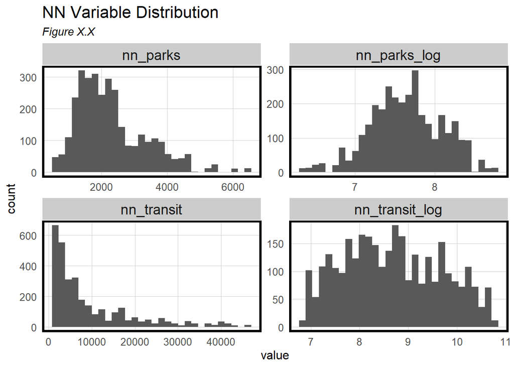

```r
dat_pred_agg %>%
  st_drop_geometry() %>%
  select(starts_with("nn_")) %>%
  pivot_longer(., cols = starts_with("nn_"), names_to = ,"variable", values_to="value") %>%
  ggplot(aes(value)) +
  geom_histogram() +
  labs(title = "NN Variable Distribution",
       subtitle = "Figure X.X") +
  facet_wrap(~variable, scales = "free") +
  plotTheme()
```

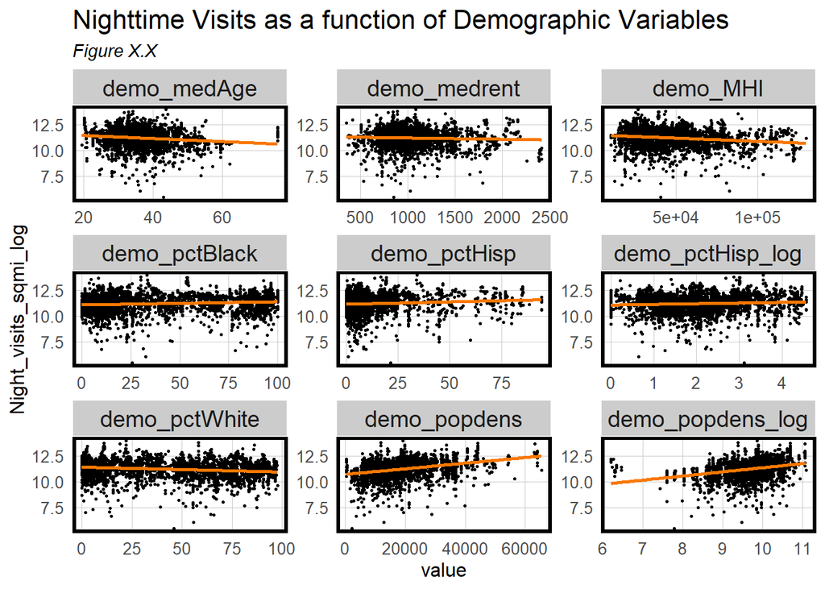

```r
##Demographic Variables
dat_pred_agg %>%
  st_drop_geometry() %>%
  pivot_longer(., cols = starts_with("demo_"), names_to = "variable", values_to="value") %>%
  ggplot(aes(value, Night_visits_sqmi_log)) +
  geom_point(size = .5) +
  geom_smooth(method = "lm", se=F, colour = "#FA7800") +
  facet_wrap(~variable, ncol = 3, scales = "free") +
  labs(title = "Nighttime Visits as a function of Demographic Variables",
       subtitle = "Figure X.X") +
  plotTheme()
```

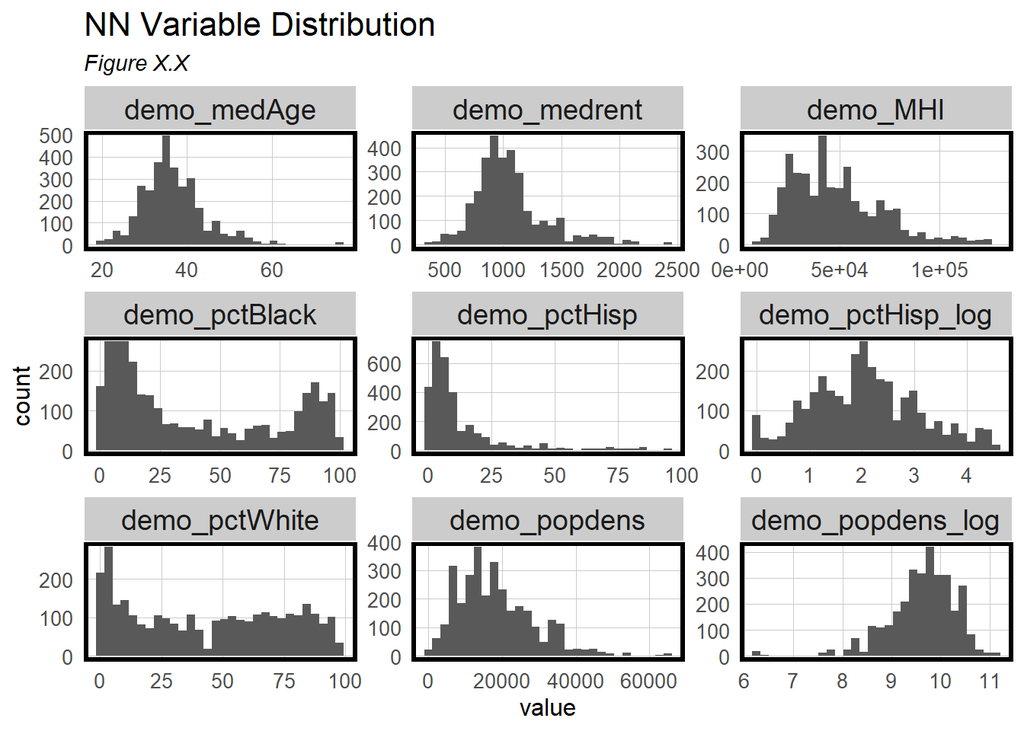

```r
dat_pred_agg %>%
  st_drop_geometry() %>%
  pivot_longer(., cols = starts_with("demo_"), names_to = ,"variable", values_to="value") %>%
  ggplot(aes(value)) +
  geom_histogram() +
  labs(title = "NN Variable Distribution",
       subtitle = "Figure X.X") +
  facet_wrap(~variable, scales = "free") +
  plotTheme()
```

## Model & Cross Validation

Using the features we engineered above, we split our data into a training and test set and run a linear regression model in the following code block. The results of the regression are shown below.

```r
#Setting up test and training datasets
set.seed(414)
inTrain <- createDataPartition(y=dat_pred_agg$Night_visits_sqmi_log, p = .60, list = FALSE)

phl.training <- dat_pred_agg[inTrain,]
phl.test <- dat_pred_agg[-inTrain,]

colnames(dat_pred_agg)
```

```
##  [1] "corridor"              "date_range_start"      "corr_type"
##  [4] "Night_visits"          "phl_area_sqmi"         "Night_visits_sqmi"
##  [7] "Night_visits_sqmi_log" "total"                 "phl_building_size"
## [10] "phl_building_size_log" "phl_building_size_med" "phl_CenterCity"
## [13] "phl_CityHall"          "phl_Temple"            "phl_UPenn"
## [16] "phl_vacrate"           "phl_vacrate_log"       "sg_dwell"
## [19] "sg_distance_home"      "sg_distance_home_log"  "count_bars_a"
## [22] "count_rest_a"          "count_arts_a"          "count_college_a"
## [25] "count_sports_a"        "count_museums_a"       "count_amuse_a"
## [28] "count_hotels_a"        "count_grocery_a"       "count_childcare_a"
## [31] "count_gas_a"           "count_religious_a"     "count_personal_a"
## [34] "count_late_tag"        "count_barpub_tag"      "count_drinks_tag"
## [37] "count_cocktail_tag"    "count_bars_a_log"      "count_rest_a_log"
## [40] "count_arts_a_log"      "count_grocery_a_log"   "count_religious_a_log"
## [43] "count_childcare_a_log" "count_amuse_a_log"     "count_barpub_log"
## [46] "count_late_log"        "nn_transit"            "nn_parks"
## [49] "nn_parks_log"          "nn_transit_log"        "demo_popdens"
## [52] "demo_popdens_log"      "demo_pctWhite"         "demo_pctBlack"
## [55] "demo_pctHisp"          "demo_medAge"           "demo_MHI"
## [58] "demo_medrent"          "demo_pctHisp_log"      "geometry"
```

```r
#Multivariate regression
reg1 <-
  lm(Night_visits_sqmi_log ~ .,
     data = st_drop_geometry(phl.training) %>%
# reg1 <- lm(Night_visits ~ ., data = new_dat %>%
             select(Night_visits_sqmi_log,
                    phl_building_size_log,
                    # phl_UPenn,
                    phl_Temple,
                    # phl_CityHall,
                    # phl_rest_sqft_log,
                    # phl_bar_sqft_log,
                    phl_vacrate_log,
                    # phl_CenterCity,
                    # sg_distance_home_log,
                    sg_dwell,
                    count_bars_a_log,
                    count_rest_a_log,
                    count_arts_a_log,
                    count_grocery_a_log,
                    # count_childcare_a_log,
                    # count_religious_a_log,
                    # count_bars_a,
                    # count_rest_a,
                    # count_arts_a,
                    # count_college_a,
                    # count_sports_a,
                    # count_museums_a,
                    # count_amuse_a_log,
                    # count_hotels_a,
                    nn_transit_log,
                    # nn_parking_log,
                    nn_parks_log,
                    # count_late_tag,
                    # count_barpub_tag,
                    corr_type,
                    count_late_log,
                    # count_barpub_log,
                    demo_pctWhite,
                    # demo_pctBlack,
                    # demo_pctHisp_log,
                    # demo_medAge,
                    # demo_popdens,
                    # demo_popdens_log,
                    demo_medrent,
                    demo_MHI)
)

summary(reg1)
```

```
##
## Call:
## lm(formula = Night_visits_sqmi_log ~ ., data = st_drop_geometry(phl.training) %>%
##     select(Night_visits_sqmi_log, phl_building_size_log, phl_Temple,
##         phl_vacrate_log, sg_dwell, count_bars_a_log, count_rest_a_log,
##         count_arts_a_log, count_grocery_a_log, nn_transit_log,
##         nn_parks_log, corr_type, count_late_log, demo_pctWhite,
##         demo_medrent, demo_MHI))
##
## Residuals:
##     Min      1Q  Median      3Q     Max
## -4.9761 -0.3329  0.0513  0.3997  2.6620
##
## Coefficients:
##                                    Estimate Std. Error t value Pr(>|t|)
## (Intercept)                       8.120e+00  4.340e-01  18.709  < 2e-16 ***
## phl_building_size_log             2.267e-03  1.755e-02   0.129  0.89727
## phl_Temple                        3.915e-06  2.022e-06   1.936  0.05298 .
## phl_vacrate_log                  -2.387e-02  1.771e-02  -1.347  0.17800
## sg_dwell                          2.321e-03  3.121e-04   7.434 1.59e-13 ***
## count_bars_a_log                 -6.728e-02  5.434e-02  -1.238  0.21585
## count_rest_a_log                  5.746e-01  2.732e-02  21.030  < 2e-16 ***
## count_arts_a_log                 -1.910e-01  3.798e-02  -5.029 5.39e-07 ***
## count_grocery_a_log               2.272e-01  3.089e-02   7.354 2.86e-13 ***
## nn_transit_log                   -1.750e-01  2.692e-02  -6.502 1.01e-10 ***
## nn_parks_log                      1.301e-01  4.693e-02   2.772  0.00562 **
## corr_type2. Neighborhood Center   8.729e-02  4.197e-02   2.080  0.03768 *
## corr_type3. Community Center      9.501e-02  6.319e-02   1.503  0.13288
## corr_type4. Regional Center       4.344e-01  1.505e-01   2.886  0.00395 **
## corr_type5. Superregional Center  1.040e+00  1.612e-01   6.454 1.38e-10 ***
## corr_type6. Speciality Center     6.712e-02  8.203e-02   0.818  0.41338
## count_late_log                    1.432e-01  5.001e-02   2.863  0.00424 **
## demo_pctWhite                    -2.742e-03  7.001e-04  -3.916 9.32e-05 ***
## demo_medrent                      1.868e-04  7.932e-05   2.355  0.01863 *
## demo_MHI                         -6.565e-06  1.121e-06  -5.856 5.57e-09 ***
## ---
## Signif. codes:  0 '***' 0.001 '**' 0.01 '*' 0.05 '.' 0.1 ' ' 1
##
## Residual standard error: 0.6475 on 1876 degrees of freedom
## Multiple R-squared:  0.4473, Adjusted R-squared:  0.4417
## F-statistic: 79.92 on 19 and 1876 DF,  p-value: < 2.2e-16
```

```r
stargazer(
  reg1,
  type = "text",
  title = "Linear Model Summary Table",
  dep.var.caption = " ",
  dep.var.labels = "Model Features")
```

```
##
## Linear Model Summary Table
## ============================================================
##
##                                  ---------------------------
##                                        Model Features
## ------------------------------------------------------------
## phl_building_size_log                       0.002
##                                            (0.018)
##
## phl_Temple                                0.00000*
##                                           (0.00000)
##
## phl_vacrate_log                            -0.024
##                                            (0.018)
##
## sg_dwell                                  0.002***
##                                           (0.0003)
##
## count_bars_a_log                           -0.067
##                                            (0.054)
##
## count_rest_a_log                          0.575***
##                                            (0.027)
##
## count_arts_a_log                          -0.191***
##                                            (0.038)
##
## count_grocery_a_log                       0.227***
##                                            (0.031)
##
## nn_transit_log                            -0.175***
##                                            (0.027)
##
## nn_parks_log                              0.130***
##                                            (0.047)
##
## corr_type2. Neighborhood Center            0.087**
##                                            (0.042)
##
```

[output cut: 20 more lines]

```
##
## demo_MHI                                 -0.00001***
##                                           (0.00000)
##
## Constant                                  8.120***
##                                            (0.434)
##
## ------------------------------------------------------------
## Observations                                1,896
## R2                                          0.447
## Adjusted R2                                 0.442
## Residual Std. Error                   0.647 (df = 1876)
## F Statistic                       79.920*** (df = 19; 1876)
## ============================================================
## Note:                            *p<0.1; **p<0.05; ***p<0.01
```

In an effort to improve our Adjust R Square value, the measure indicating how well our model fits the data, we are trying to remove outliers in the data. The following box plot shows the the distribution of the dependent variable (the log of nighttime visits normalized by corridor area) and indicates where there are outliers. **Question should we be removing outliers along another metric?**

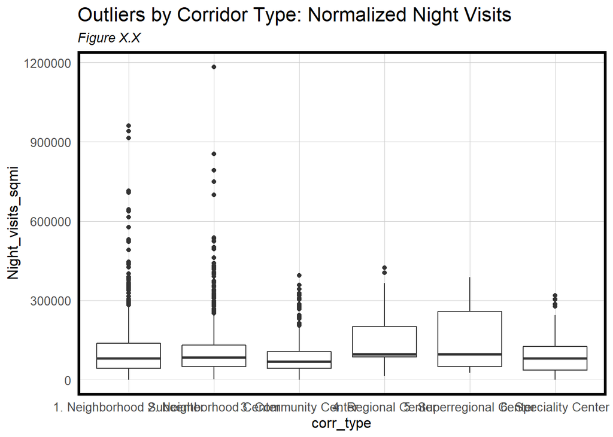

```r
dat_pred_agg %>%
  select(Night_visits_sqmi, corr_type) %>%
  ggplot(., aes(x = Night_visits_sqmi, y = corr_type)) +
  geom_boxplot() +
  coord_flip() +
  labs(title = "Outliers by Corridor Type: Normalized Night Visits",
       subtitle = "Figure X.X") +
  plotTheme()
```

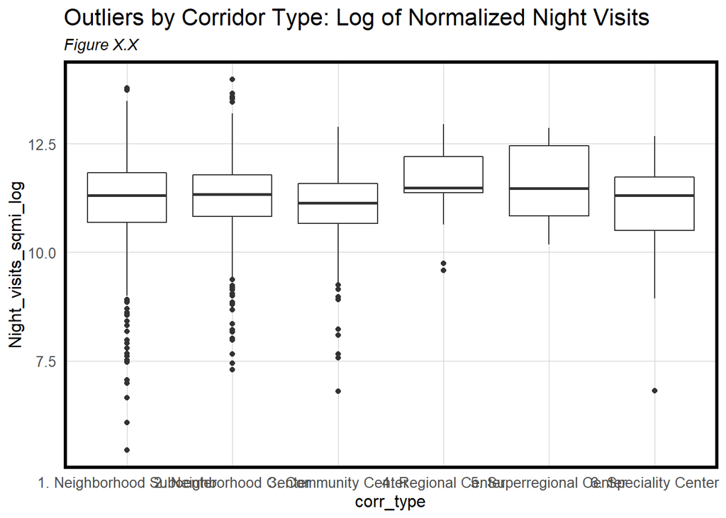

```r
dat_pred_agg %>%
  select(Night_visits_sqmi_log, corr_type) %>%
  ggplot(., aes(x = Night_visits_sqmi_log, y = corr_type)) +
  geom_boxplot() +
  coord_flip() +
  labs(title = "Outliers by Corridor Type: Log of Normalized Night Visits",
       subtitle = "Figure X.X") +
  plotTheme()
```

Next we code a second regression using the same features but with a subset of the data. The below output shows a comparison of the two regressions.

```r
#Removing outliers
dat_pred_agg_sub <- dat_pred_agg %>% filter(Night_visits_sqmi < 600000)

#Setting up test and training datasets
set.seed(414)
inTrain <- createDataPartition(y=dat_pred_agg_sub$Night_visits_sqmi_log, p = .60, list = FALSE)

phl.training.sub <- dat_pred_agg_sub[inTrain,]
phl.test.sub <- dat_pred_agg_sub[-inTrain,]

#Multivariate regression
reg1.sub <-
  lm(Night_visits_sqmi_log ~ .,
     data = st_drop_geometry(phl.training.sub) %>%
# reg1 <- lm(Night_visits ~ ., data = new_dat %>%
             select(Night_visits_sqmi_log,
                    phl_building_size_log,
                    # phl_UPenn,
                    phl_Temple,
                    # phl_CityHall,
                    # phl_rest_sqft_log,
                    # phl_bar_sqft_log,
                    phl_vacrate_log,
                    # phl_CenterCity,
                    # sg_distance_home_log,
                    sg_dwell,
                    count_bars_a_log,
                    count_rest_a_log,
                    count_arts_a_log,
                    count_grocery_a_log,
                    # count_childcare_a_log,
                    # count_religious_a_log,
                    # count_bars_a,
                    # count_rest_a,
                    # count_arts_a,
                    # count_college_a,
                    # count_sports_a,
                    # count_museums_a,
                    # count_amuse_a_log,
                    # count_hotels_a,
                    nn_transit_log,
                    # nn_parking_log,
                    nn_parks_log,
                    # count_late_tag,
                    # count_barpub_tag,
                    corr_type,
                    count_late_log,
                    # count_barpub_log,
                    demo_pctWhite,
                    # demo_pctBlack,
                    # demo_pctHisp_log,
                    # demo_medAge,
                    # demo_popdens,
                    # demo_popdens_log,
                    demo_medrent,
                    demo_MHI)
)

# summary(reg1.sub)

stargazer(
  reg1, reg1.sub,
  type = "text",
  title = "Linear Model Summary Table",
  dep.var.caption = " ",
  dep.var.labels = "Model Features")
```

```
##
## Linear Model Summary Table
## ====================================================================================
##
##                                  ---------------------------------------------------
##                                                    Model Features
##                                             (1)                       (2)
## ------------------------------------------------------------------------------------
## phl_building_size_log                      0.002                     0.002
##                                           (0.018)                   (0.017)
##
## phl_Temple                               0.00000*                  0.00000*
##                                          (0.00000)                 (0.00000)
##
## phl_vacrate_log                           -0.024                    -0.023
##                                           (0.018)                   (0.017)
##
## sg_dwell                                 0.002***                  0.002***
##                                          (0.0003)                  (0.0003)
##
## count_bars_a_log                          -0.067                    -0.049
##                                           (0.054)                   (0.053)
##
## count_rest_a_log                         0.575***                  0.568***
##                                           (0.027)                   (0.026)
##
## count_arts_a_log                         -0.191***                 -0.218***
##                                           (0.038)                   (0.037)
##
## count_grocery_a_log                      0.227***                  0.217***
##                                           (0.031)                   (0.029)
##
## nn_transit_log                           -0.175***                 -0.165***
##                                           (0.027)                   (0.026)
##
## nn_parks_log                             0.130***                  0.139***
##                                           (0.047)                   (0.046)
##
## corr_type2. Neighborhood Center           0.087**                    0.059
##                                           (0.042)                   (0.041)
```

[output cut: 21 more lines]

```
##
## demo_MHI                                -0.00001***               -0.00001***
##                                          (0.00000)                 (0.00000)
##
## Constant                                 8.120***                  8.130***
##                                           (0.434)                   (0.424)
##
## ------------------------------------------------------------------------------------
## Observations                               1,896                     1,890
## R2                                         0.447                     0.455
## Adjusted R2                                0.442                     0.450
## Residual Std. Error                  0.647 (df = 1876)         0.628 (df = 1870)
## F Statistic                      79.920*** (df = 19; 1876) 82.323*** (df = 19; 1870)
## ====================================================================================
## Note:                                                    *p<0.1; **p<0.05; ***p<0.01
```

Both models’ errors are summarized in the following table. Currently we see that the subset of data does not have a particularly noticeable impact on the model’s accuracy.

*Question*: Is the Night_visits_sqmi the proper variable to compare to the exponentiated prediction?

```r
phl.test <-
  phl.test %>%
  st_drop_geometry() %>%
  mutate(Regression = "Baseline Regression",
         Visits.Predict = exp(predict(reg1, phl.test)),
         Visits.Error = Visits.Predict - Night_visits_sqmi,
         Visits.AbsError = abs(Visits.Predict - Night_visits_sqmi),
         Visits.APE = (abs(Visits.Predict - Night_visits_sqmi)) / Visits.Predict)

phl.test.sub <-
  phl.test.sub %>%
  st_drop_geometry() %>%
  mutate(Regression = "Baseline Regression",
         Visits.Predict = exp(predict(reg1.sub, phl.test.sub)),
         Visits.Error = Visits.Predict - Night_visits_sqmi,
         Visits.AbsError = abs(Visits.Predict - Night_visits_sqmi),
         Visits.APE = (abs(Visits.Predict - Night_visits_sqmi)) / Visits.Predict)

# ErrorTable <-
#   phl.test %>%
#   dplyr::summarize(Regression = "Baseline Regression",
#                    MAE = mean(Visits.AbsError, na.rm = T),
#                    MAPE = mean(Visits.AbsError, na.rm = T) / mean(Night_visits_sqmi, na.rm = T))

ErrorTable <-
  rbind(phl.test %>%
        dplyr::summarize(Regression = "Baseline Regression",
                   MAE = mean(Visits.AbsError, na.rm = T),
                   MAPE = mean(Visits.AbsError, na.rm = T) / mean(Night_visits_sqmi, na.rm = T)),
      phl.test.sub %>%
        dplyr::summarize(Regression = "Subset Regression",
                   MAE = mean(Visits.AbsError, na.rm = T),
                   MAPE = mean(Visits.AbsError, na.rm = T) / mean(Night_visits_sqmi, na.rm = T)))

ErrorTable %>%
  group_by(Regression) %>%
  arrange(desc(MAE)) %>%
  kable(caption = "MAE and MAPE for Test Set Data") %>% kable_styling()
```

MAE and MAPE for Test Set Data

| Regression | MAE | MAPE |
| --- | --- | --- |
| Baseline Regression | 43532.70 | 0.4269896 |
| Subset Regression | 41596.54 | 0.4152005 |

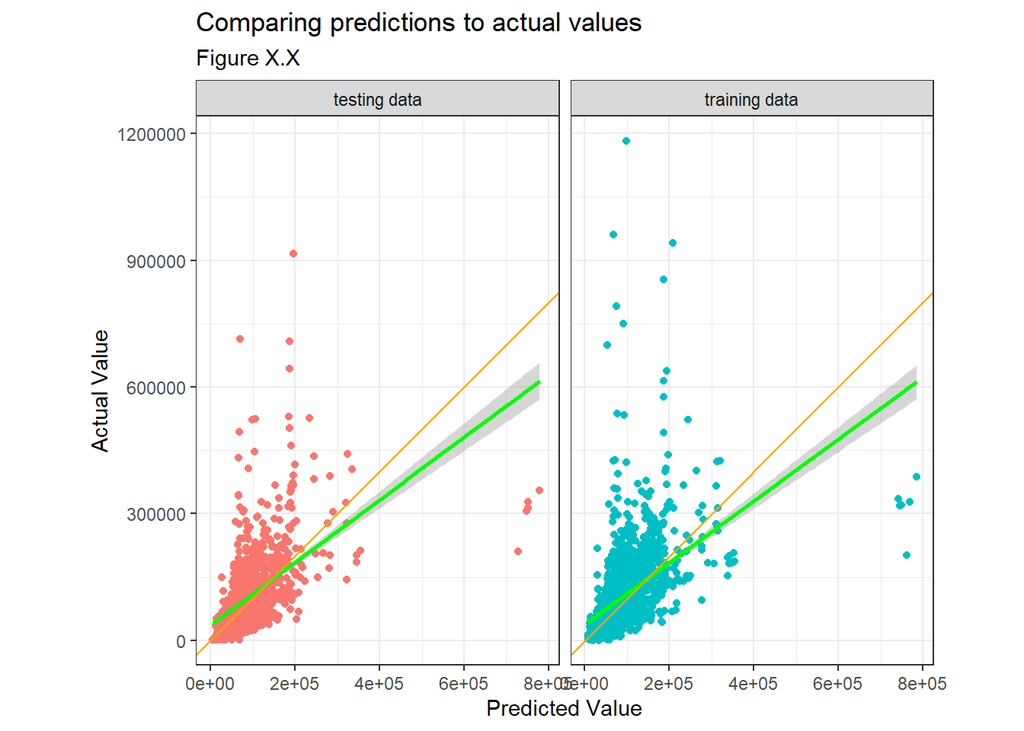

```r
reg1_predict <- exp(predict(reg1, newdata = phl.test))

# View(test)
# length(exp(predict(reg1)))
# length(phl.training$Night_visits_sqmi)
#
# summary(phl.training)

rmse.train <- caret::MAE(exp(predict(reg1)), phl.training$Night_visits_sqmi)
rmse.test <- caret::MAE(reg1_predict, phl.test$Night_visits_sqmi)

preds.train <- data.frame(pred   = exp(predict(reg1)),
                          actual = phl.training$Night_visits_sqmi,
                          source = "training data")
preds.test  <- data.frame(pred   = reg1_predict,
                          actual = phl.test$Night_visits_sqmi,
                          source = "testing data")

preds <- rbind(preds.train, preds.test)

ggplot(preds, aes(x = pred, y = actual, color = source)) +
  geom_point() +
  geom_smooth(method = "lm", color = "green") +
  geom_abline(color = "orange") +
  theme_bw() +
  coord_equal() +
  facet_wrap(~source, ncol = 2) +
  labs(title = "Comparing predictions to actual values",
       x = "Predicted Value",
       y = "Actual Value",
       subtitle = "Figure X.X") +
  theme(
    legend.position = "none"
  )
```

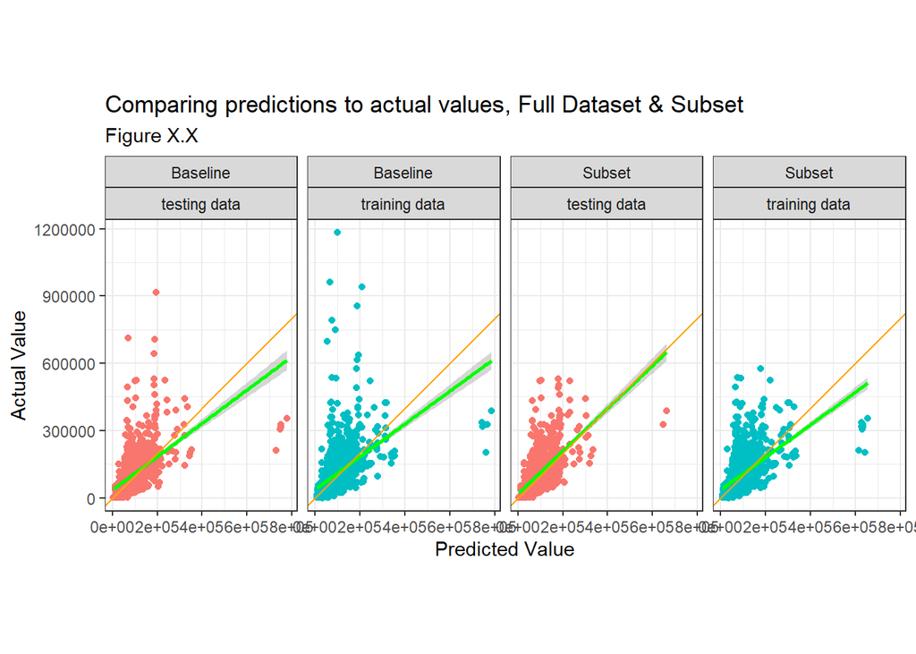

```r
reg1.sub_predict <- exp(predict(reg1.sub, newdata = phl.test.sub))

# View(test)
# length(exp(predict(reg1)))
# length(phl.training$Night_visits_sqmi)
#
# summary(phl.training)

rmse.train.sub <- caret::MAE(exp(predict(reg1.sub)), phl.training.sub$Night_visits_sqmi)
rmse.test.sub <- caret::MAE(reg1.sub_predict, phl.test.sub$Night_visits_sqmi)

preds.train.sub <- data.frame(pred   = exp(predict(reg1.sub)),
                          actual = phl.training.sub$Night_visits_sqmi,
                          source = "training data")
preds.test.sub  <- data.frame(pred   = reg1.sub_predict,
                          actual = phl.test.sub$Night_visits_sqmi,
                          source = "testing data")

preds.sub <- rbind(preds.train.sub, preds.test.sub)

preds.all <- rbind(preds %>% mutate(Regression = "Baseline"),
                   preds.sub %>% mutate(Regression = "Subset"))

ggplot(preds.all, aes(x = pred, y = actual, color = source)) +
  geom_point() +
  geom_smooth(method = "lm", color = "green") +
  geom_abline(color = "orange") +
  theme_bw() +
  coord_equal() +
  facet_wrap(~Regression+source, ncol = 4) +
  labs(title = "Comparing predictions to actual values, Full Dataset & Subset",
       x = "Predicted Value",
       y = "Actual Value",
       subtitle = "Figure X.X") +
  theme(
    legend.position = "none"
  )
```

We also test for generalizability with cross validation for the full dataset with the below code. The plot shows the Mean Average Error across 100 folds.

```r
fitControl <- trainControl(method = "cv",
                           number = 100,
                           savePredictions = TRUE)

set.seed(414)
reg1.cv <-
  train(Night_visits_sqmi_log ~ ., data = st_drop_geometry(dat_pred_agg) %>%
          dplyr::select(Night_visits_sqmi_log,
                    phl_building_size_log,
                    # phl_UPenn,
                    phl_Temple,
                    # phl_CityHall,
                    # phl_rest_sqft_log,
                    # phl_bar_sqft_log,
                    phl_vacrate_log,
                    # phl_CenterCity,
                    # sg_distance_home_log,
                    sg_dwell,
                    count_bars_a_log,
                    count_rest_a_log,
                    count_arts_a_log,
                    count_grocery_a_log,
                    # count_childcare_a_log,
                    # count_religious_a_log,
                    # count_bars_a,
                    # count_rest_a,
                    # count_arts_a,
                    # count_college_a,
                    # count_sports_a,
                    # count_museums_a,
                    # count_amuse_a_log,
                    # count_hotels_a,
                    nn_transit_log,
                    # nn_parking_log,
                    nn_parks_log,
                    # count_late_tag,
                    # count_barpub_tag,
                    corr_type,
                    count_late_log,
                    # count_barpub_log,
                    demo_pctWhite,
                    # demo_pctBlack,
                    # demo_pctHisp_log,
                    # demo_medAge,
                    # demo_popdens,
                    # demo_popdens_log,
                    demo_medrent,
                    demo_MHI),
        method = "lm",
        trControl = fitControl,
        na.action = na.pass)

reg1.cv.resample <- reg1.cv$resample

reg1.cv
```

```
## Linear Regression
##
## 3159 samples
##   15 predictor
##
## No pre-processing
## Resampling: Cross-Validated (100 fold)
## Summary of sample sizes: 3128, 3128, 3127, 3128, 3130, 3127, ...
## Resampling results:
##
##   RMSE       Rsquared   MAE
##   0.6346089  0.4701283  0.4766918
##
## Tuning parameter 'intercept' was held constant at a value of TRUE
```

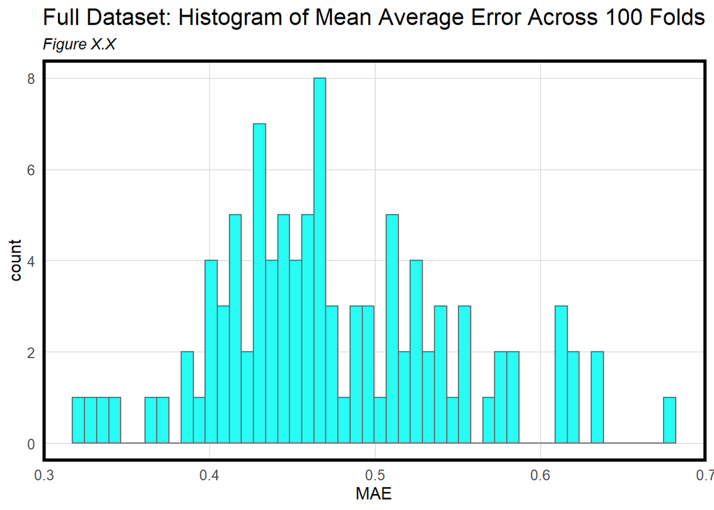

```r
ErrorHist <-
  ggplot(reg1.cv.resample, aes(x=MAE)) +
  geom_histogram(color = "grey40", fill = "#27fdf5", bins = 50) +
  labs(title="Full Dataset: Histogram of Mean Average Error Across 100 Folds",
       subtitle = "Figure X.X") +
  plotTheme()

ErrorHist
```

We generate the same histogram with the subset data. The errors across the two regressions are farily uniform.

```r
reg1.sub.cv <-
  train(Night_visits_sqmi_log ~ ., data = st_drop_geometry(dat_pred_agg_sub) %>%
          dplyr::select(Night_visits_sqmi_log,
                    phl_building_size_log,
                    # phl_UPenn,
                    phl_Temple,
                    # phl_CityHall,
                    # phl_rest_sqft_log,
                    # phl_bar_sqft_log,
                    phl_vacrate_log,
                    # phl_CenterCity,
                    # sg_distance_home_log,
                    sg_dwell,
                    count_bars_a_log,
                    count_rest_a_log,
                    count_arts_a_log,
                    count_grocery_a_log,
                    # count_childcare_a_log,
                    # count_religious_a_log,
                    # count_bars_a,
                    # count_rest_a,
                    # count_arts_a,
                    # count_college_a,
                    # count_sports_a,
                    # count_museums_a,
                    # count_amuse_a_log,
                    # count_hotels_a,
                    nn_transit_log,
                    # nn_parking_log,
                    nn_parks_log,
                    # count_late_tag,
                    # count_barpub_tag,
                    corr_type,
                    count_late_log,
                    # count_barpub_log,
                    demo_pctWhite,
                    # demo_pctBlack,
                    # demo_pctHisp_log,
                    # demo_medAge,
                    # demo_popdens,
                    # demo_popdens_log,
                    demo_medrent,
                    demo_MHI),
        method = "lm",
        trControl = fitControl,
        na.action = na.pass)

reg1.sub.cv.resample <- reg1.sub.cv$resample

reg1.sub.cv
```

```
## Linear Regression
##
## 3146 samples
##   15 predictor
##
## No pre-processing
## Resampling: Cross-Validated (100 fold)
## Summary of sample sizes: 3115, 3115, 3115, 3114, 3114, 3114, ...
## Resampling results:
##
##   RMSE       Rsquared   MAE
##   0.6231715  0.4789727  0.4721505
##
## Tuning parameter 'intercept' was held constant at a value of TRUE
```

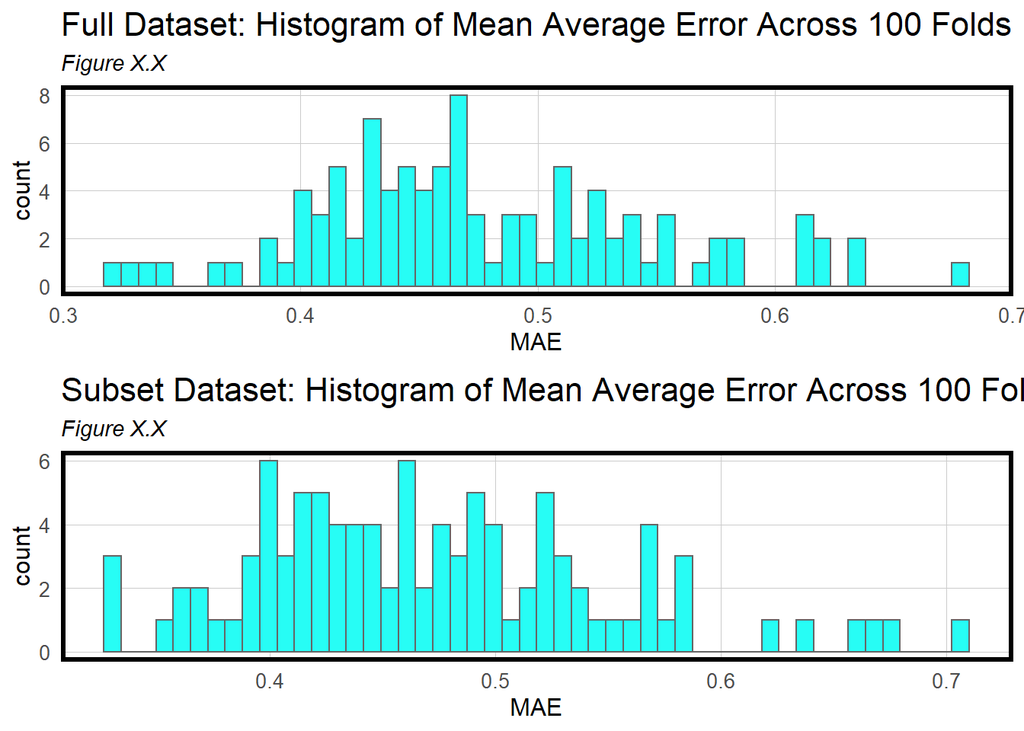

```r
ErrorHist.sub <-
  ggplot(reg1.sub.cv.resample, aes(x=MAE)) +
  geom_histogram(color = "grey40", fill = "#27fdf5", bins = 50) +
  labs(title="Subset Dataset: Histogram of Mean Average Error Across 100 Folds",
       subtitle = "Figure X.X") +
  plotTheme()

grid.arrange(ErrorHist, ErrorHist.sub, ncol=1)
```

Finally, we map the errors by commercial corridor in the following figures. The absolute errors indicate that our model is less accurate predicting nighttime traffic for larger, more heavily-trafficked corridors. The Percent Errors map on the right, actually tells a slightly different story with the highest quintile of percent error along the smaller corridors throughout the city. We have only produced this graphic for the full dataset.

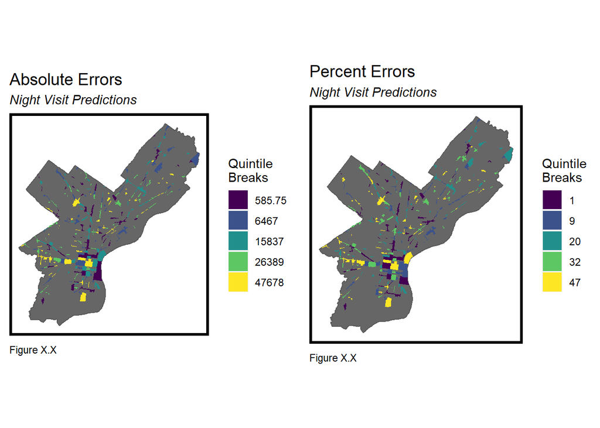

```r
cv_preds <- reg1.cv$pred

map_preds <- dat_pred_agg %>%
  rowid_to_column(var = "rowIndex") %>%
  left_join(cv_preds, by = "rowIndex") %>%
  group_by(corridor, corr_type) %>% #CONFIRM THIS APPROACH WITH MATT!
  summarise(Night_visits_sqmi = mean(Night_visits_sqmi),
            pred = mean(pred)) %>%
  mutate(Visits.AbsError = abs(exp(pred) - Night_visits_sqmi),
         PercentError = (Visits.AbsError / Night_visits_sqmi)*100)

ErrorPlot1 <- ggplot() +
  geom_sf(data = phl_boundary, fill = "grey40") +
  geom_sf(data = map_preds, aes(fill = q5(Visits.AbsError)), color = "transparent") +
  scale_fill_manual(values = palette5,
                      labels=qBr(map_preds,"Visits.AbsError"),
                      name="Quintile\nBreaks") +
  labs(title="Absolute Errors",
       subtitle = "Night Visit Predictions",
       caption = "Figure X.X") +
  mapTheme()

ErrorPlot2 <- ggplot() +
  geom_sf(data = phl_boundary, fill = "grey40") +
  geom_sf(data = map_preds, aes(fill = q5(PercentError)), color = "transparent") +
  scale_fill_manual(values = palette5,
                      labels=qBr(map_preds, "PercentError"),
                      name="Quintile\nBreaks") +
  labs(title="Percent Errors",
       subtitle = "Night Visit Predictions",
       caption = "Figure X.X") +
  mapTheme()

grid.arrange(ErrorPlot1, ErrorPlot2, ncol=2)
```

Lastly, here we see the percent errors by corridor type. We seem to be best at predicting smaller corridors that are further from Center City. We have only produced this graphic for the full dataset.

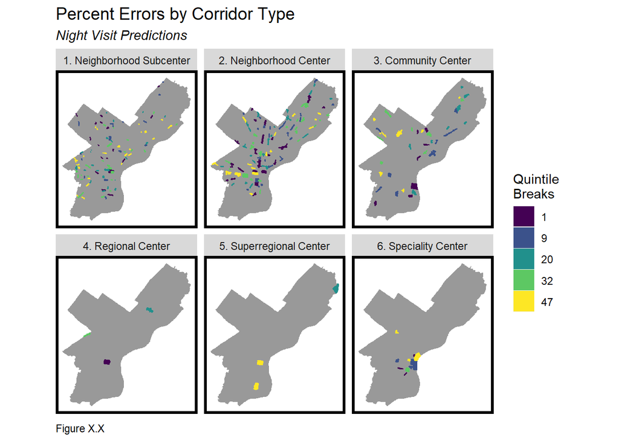

```r
map_preds %>%
  # left_join(., st_drop_geometry(phl_corridors_pred), by = "corridor") %>%
  # drop_na(corr_type) %>%
  st_as_sf() %>%
  ggplot() +
  geom_sf(data = phl_boundary, fill = 'grey60', color = "transparent") +
  geom_sf(aes(fill = q5(PercentError), color = q5(PercentError))) +
  scale_fill_manual(values = palette5,
                      labels=qBr(map_preds, "PercentError"),
                      name="Quintile\nBreaks") +
    scale_colour_manual(values = palette5,
                      labels=qBr(map_preds, "PercentError"),
                      name="Quintile\nBreaks") +
  labs(title="Percent Errors by Corridor Type",
       subtitle = "Night Visit Predictions",
       caption = "Figure X.X") +
  mapTheme() +
  facet_wrap(~corr_type)
```

# 5. Next Steps

For next week, we will primarily focus on preparing our presentation by doing the following:

- Continue to improve model.
- App development.